# R you ready to ggplot2?

### PRACTICE TIME!!

```
  year state stores
1 2005    FL    174
2 2005    MI     76
3 2005    NJ     41
4 2005    NV     22
5 2005    VT      4
```

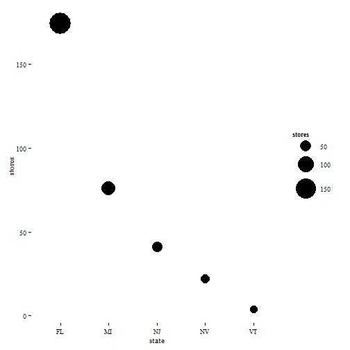

```r
# WHAT ADDITIONAL AESTHETIC MAPPING IS NEEDED TO PRODUCE THIS PLOT?
aes(x = state,y = stores)
data = mini_walmart
```

### PRACTICE TIME!!

```
  year state stores
1 2005    FL    174
2 2005    MI     76
3 2005    NJ     41
4 2005    NV     22
5 2005    VT      4
```

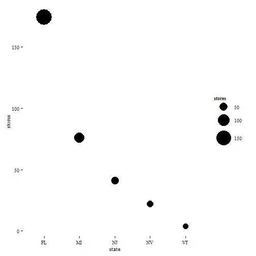

```r
# WHAT ADDITIONAL AESTHETIC MAPPING IS NEEDED TO PRODUCE THIS PLOT?
aes(x = state,y = stores,
   size = stores)
data = mini_walmart
```

### SCALE

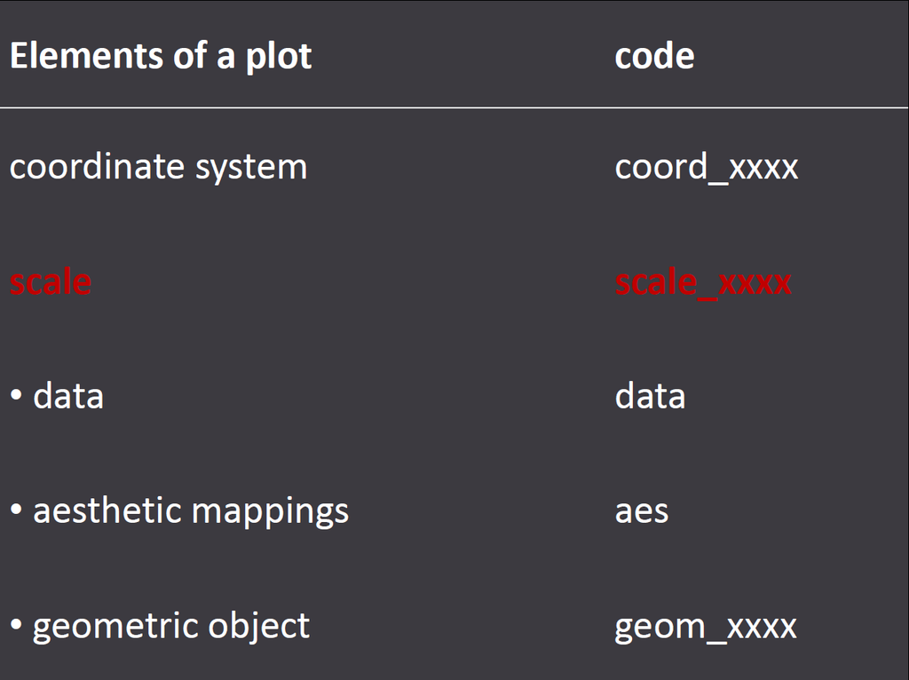

### Scale: position (default)

```
  year state stores
1 2005    FL    174
2 2005    MI     76
3 2005    NJ     41
4 2005    NV     22
5 2005    VT      4
```

```r
aes(x = state,y = stores)
data = mini_walmart
```

### Scale: position (default)

```
  year state stores
1 2005    FL    174
2 2005    MI     76
3 2005    NJ     41
4 2005    NV     22
5 2005    VT      4
```

```r
aes(x = state,y = stores)
data = mini_walmart
scale_y_continuous()
```

### Scale: position (log)

```
  year state stores
1 2005    FL    174
2 2005    MI     76
3 2005    NJ     41
4 2005    NV     22
5 2005    VT      4
```

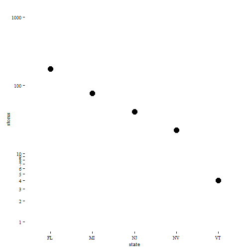

```r
aes(x = state,y = stores)
data = mini_walmart
scale_y_log10()
```

### Scale: color

```
  year state stores
1 2005    FL    174
2 2005    MI     76
3 2005    NJ     41
4 2005    NV     22
5 2005    VT      4
```

```r
aes(x = state,y = stores,
   color = stores)
data = mini_walmart
```

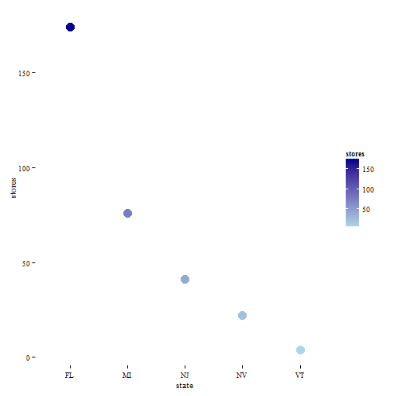

### Scale: color

```
  year state stores
1 2005    FL    174
2 2005    MI     76
3 2005    NJ     41
4 2005    NV     22
5 2005    VT      4
```

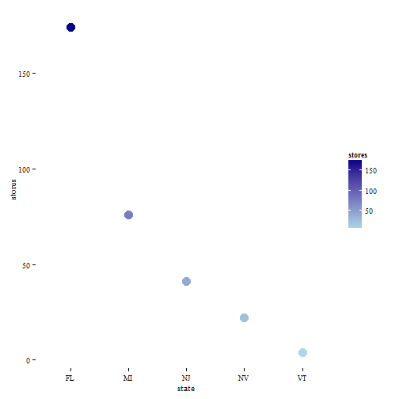

```r
aes(x = state,y = stores,
    color = stores)
data = mini_walmart
scale_color_continuous()
```

### Scale: color

```
  year state stores
1 2005    FL    174
2 2005    MI     76
3 2005    NJ     41
4 2005    NV     22
5 2005    VT      4
```

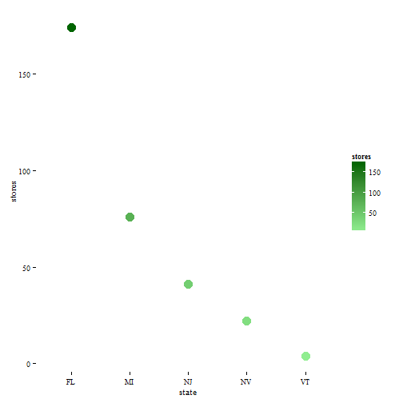

```r
aes(x = state,y = stores,
    color = stores)
data = mini_walmart
scale_color_continuous(
  low = 'light green',
  high = 'dark green')
```

### DON'T FORGET...

1. ONE aesthetic = ONE scale
2. TWO aesthetics = TWO scales
3. THREE aesthetics = THREE scales…
4. … you get the idea!

### Geometric objects: point

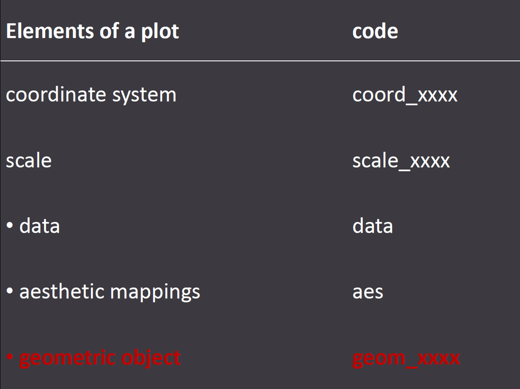

### Geometric objects: point

```
  year state stores
1 2005    FL    174
2 2005    MI     76
3 2005    NJ     41
4 2005    NV     22
5 2005    VT      4
```

```r
aes(x = state,y = stores)
data = mini_walmart
```

### Geometric objects: point

```
  year state stores
1 2005    FL    174
2 2005    MI     76
3 2005    NJ     41
4 2005    NV     22
5 2005    VT      4
```

```r
aes(x = state,y = stores)
data = mini_walmart
geom_point()
```

### Geometric objects: bar

```
  year state stores
1 2005    FL    174
2 2005    MI     76
3 2005    NJ     41
4 2005    NV     22
5 2005    VT      4
```

```r
aes(x = state,y = stores)
data = mini_walmart
geom_bar()
```

TAKE A GUESS: WHAT WILL THIS PLOT LOOK LIKE?

### Geometric objects: bar

```
  year state stores
1 2005    FL    174
2 2005    MI     76
3 2005    NJ     41
4 2005    NV     22
5 2005    VT      4
```

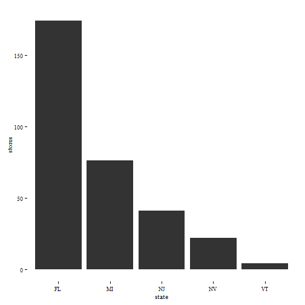

```r
aes(x = state,y = stores)
data = mini_walmart
geom_bar()
```

### PRACTICE TIME!!

```
  year state stores
1 2005    FL    174
2 2005    MI     76
3 2005    NJ     41
4 2005    NV     22
5 2005    VT      4
```

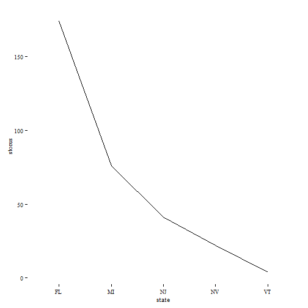

```r
# COMPLETE THE CODE TO PRODUCE THIS PLOT
aes(x = state,y = stores)
data = mini_walmart
```

### PRACTICE TIME!!

```
  year state stores
1 2005    FL    174
2 2005    MI     76
3 2005    NJ     41
4 2005    NV     22
5 2005    VT      4
```

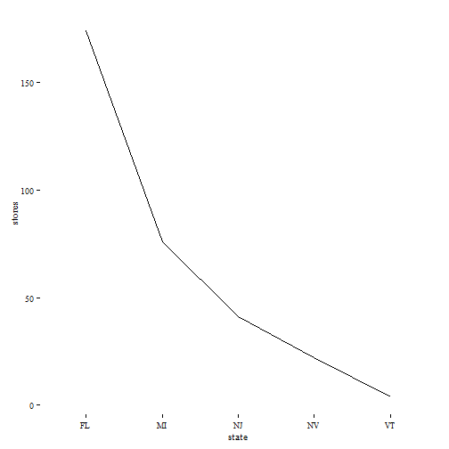

```r
# COMPLETE THE CODE TO PRODUCE THIS PLOT
aes(x = state,y = stores)
data = mini_walmart
geom_line()
```

### Geometric objects: text

```
  year state stores
1 2005    FL    174
2 2005    MI     76
3 2005    NJ     41
4 2005    NV     22
5 2005    VT      4
```

```r
aes(x = state,y = stores)
data = mini_walmart
geom_text()
```

TAKE A GUESS: WHAT WILL THIS PLOT LOOK LIKE?

### Geometric objects: text

```
  year state stores
1 2005    FL    174
2 2005    MI     76
3 2005    NJ     41
4 2005    NV     22
5 2005    VT      4
```

```r
aes(x = state,y = stores)
data = mini_walmart
geom_text()
```

Error: geom_text requires the following missing aesthetics: label

### Geometric objects: text

```
  year state stores
1 2005    FL    174
2 2005    MI     76
3 2005    NJ     41
4 2005    NV     22
5 2005    VT      4
```

```r
aes(x = state,y = stores)
data = mini_walmart
geom_text()
```

What happened here? ggplot2 knows what a point is. It also knows what a bar is. However, when you tell ggplot2 to use **text** to represent your data, ggplot2 doesn't know **which text** to display… This needs to be explicitly specified.

### Geometric objects: text

```
  year state stores
1 2005    FL    174
2 2005    MI     76
3 2005    NJ     41
4 2005    NV     22
5 2005    VT      4
```

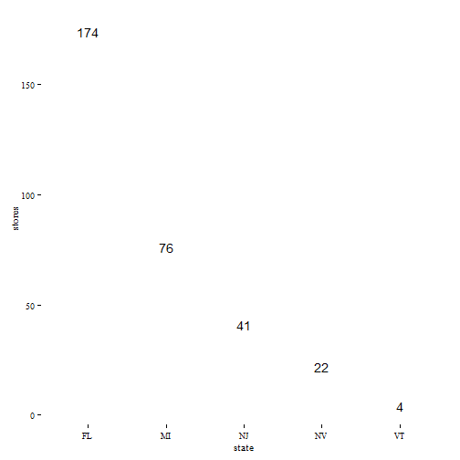

```r
aes(x = state,y = stores,
  label = stores)
data = mini_walmart
geom_text()
```

### Position adjustment: identity

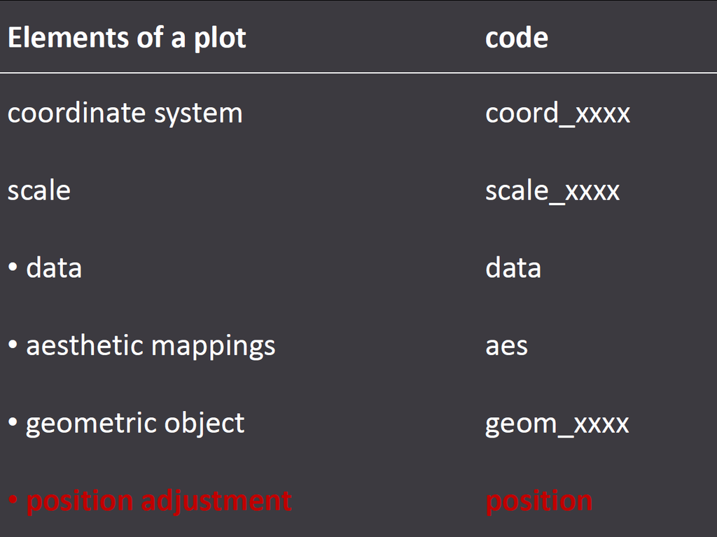

Geometric objects sometimes overlap. The **position adjustment** is another key element of the Grammar of Graphics that specifically addresses this issue

### Position adjustment: identity

```
  year state stores
1 2005    FL    174
2 2005    MI     76
3 2005    NJ     41
4 2005    NV     22
5 2005    VT      4
```

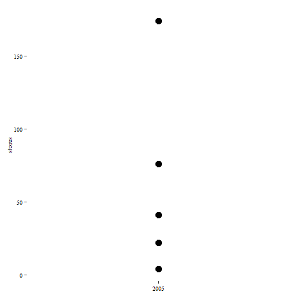

```r
aes(x = year,y = stores)
data = mini_walmart
geom_point()
```

### Position adjustment: identity

```
  year state stores
1 2005    FL    174
2 2005    MI     76
3 2005    NJ     41
4 2005    NV     22
5 2005    VT      4
```

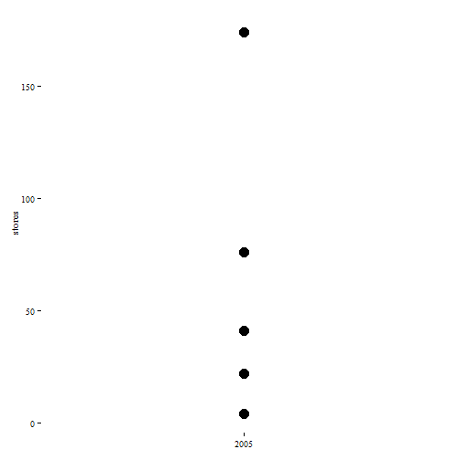

```r
aes(x = year,y = stores)
data = mini_walmart
geom_point()
position = 'identity'
```

### Position adjustment: identity

```
  year state stores
1 2005    FL    174
2 2005    MI     76
3 2005    NJ     41
4 2005    NV     22
5 2005    VT      4
```

```r
aes(x = year,y = stores)
data = mini_walmart
geom_bar()
position = identity
```

TAKE A GUESS: WHAT WILL THIS PLOT LOOK LIKE?